# TRANSFORMACIONES DE DATOS COMO MEDIDAS REMEDIALES EN EL MARCO DEL MODELO DE REGRESIÓN LINEAL (DATA TRANSFORMATIONS AS REMEDIAL MEASURES WITHIN THE FRAMEWORK OF THE LINEAR REGRESSION MODEL)

JOSÉ M. GÓMEZ

7/11/2021

# CASO DE APLICACIÓN: NÚMERO DE ESPECIE DE PLANTAS ENCONTRADAS EN EL ARCHIPIÉLAGO GALÁPAGOS

## A. EJEMPLOS DE TRANSFORMACIONES PARA CORRECCIÓN DE HETEROCEDASTICIDAD

Se cuenta con la información de 30 islas del Archipiélago Galápagos. Interesa analizar la relación entre el número de especies de plantas encontradas en cada isla y algunas variables geográficas.

1. **especies**: número de especies de plantas.
2. **endemicas**: número de especies endémicas.
3. **area**: área de la isla ($km^2$).
4. **elevacion**: elevación del punto más alto de la isla ($m$).
5. **cercana**: distancia a la isla más cercana ($km$).
6. **scruz**: distancia a la isla Santa Cruz ($km$).
7. **adyacente**: área de la isla adyacente ($km^2$).
1. Puede ajustarse un modelo, por ejemplo, que tenga como predictores a todas las variables de la base de datos, con excepción de **endemicas**. Tras ello, es recomendable verificar si se cumple el supuesto de homogeneidad de varianza u **homocedasticidad**.

```r
library(lmtest)
mod1 = lm(especies ~ .-endemicas,base)
#Contraste Breusch-Pagan
bptest(mod1,studentize=F)
```

```
##
##  Breusch-Pagan test
##
## data:  mod1
## BP = 21.423, df = 5, p-value = 0.0006737
```

```r
#Contraste de White (Contraste Breusch-Pagan Studentizado)
bptest(mod1,studentize=T)
```

```
##
##  studentized Breusch-Pagan test
##
## data:  mod1
## BP = 9.7959, df = 5, p-value = 0.08123
```

La probabilidad asociada en el contraste de Breush-Pagan es muy baja (0.00067), por lo que se rechaza la hipótesis nula de homoscedasticidad; se concluye que no se cumple este supuesto. Sin embargo, el contraste de White muestra que a una significancia de 0.05 y 0.01 se aceptaría la hipótesis nula; nótese que el contraste de White es una versión robustecida del contraste de Breusch-Pagan. A pesar de lo anterior, por fines didácticos se trabajará únicamente con los resultados de la prueba Breusch-Pagan.

2. En relación al resultado anterior, puede estudiarse el efecto que tiene el transformar la variable de respuesta mediante la adición o multiplicación de una constante. Para ello pueden contruirse dos modelos, uno en el que se sume (por ejemplo) 1 a la respuesta y otro en el que se multiplique dicha respuesta (por ejemplo) por 1.2; es recomendable almacenar los coeficientes de los tres modelos (el primero que se hizo -`mod`- y los dos que están por hacerse -`mod2` y `mod3`-) en una sola matriz con ayuda de la sintaxis `cbind`.

```r
mod2 = lm(I(especies+1) ~ .-endemicas,base)
mod3 = lm(I(especies*1.2) ~ .-endemicas,base)
cbind(mod1$coef, mod2$coef, mod3$coef)
```

```
##                     [,1]         [,2]        [,3]
## (Intercept)  7.068220709  8.068220709  8.48186485
## area        -0.023938338 -0.023938338 -0.02872601
## elevacion    0.319464761  0.319464761  0.38335771
## cercana      0.009143961  0.009143961  0.01097275
## scruz       -0.240524230 -0.240524230 -0.28862908
## adyacente   -0.074804832 -0.074804832 -0.08976580
```

De lo anterior se observa que el modelo en que se suma una constante tiene los mismos coeficientes-pendiente para todas las variables, pero diferente coeficiente-intercepto. Finalmente, el modelo en que se multiplica a la respuesta por una constante cambian todos los coeficientes.

3. Antes se estimaron los coeficientes de regresión del modelo vía mínimos cuadrados ordinarios (MCO), pero también es posible estimarlos vía la maximización del logaritmo de la verosimilitud (MLE) de cada uno de los modelos. ¿Sería posible con tal resultado analizar y comparar su robustez estadística?. Para la calcular los coeficientes por MLE puede utilizarse la sintaxis `logLik(mod)`.

```r
logLik(mod1)
```

```
## 'log Lik.' -162.535 (df=7)
```

```r
logLik(mod2)
```

```
## 'log Lik.' -162.535 (df=7)
```

```r
logLik(mod3)
```

```
## 'log Lik.' -168.0047 (df=7)
```

Como se señala en https://towardsdatascience.com/probability-concepts-explained-maximum-likelihood-estimation-c7b4342fdbb1, la estimación de máxima verosimilitud, en este contexto, es un método que determina valores para los coeficientes de regresión de un modelo. Los valores de tales coeficientes se encuentran de tal manera que maximizan la probabilidad de que el proceso descrito por el modelo produzca los datos que realmente se observaron (la verosimilityd); se habla del logaritmo de la verosimilitud porque computacionalmente es más fácil maximizar el logaritmo de la función de verosimilitud que maximizar la función de verosimilitud, específicamente en lo relativo al proceso de diferenciación de la función.

La minimización de mínimos cuadrados es otro método común para estimar valores de parámetros para un modelo en el aprendizaje automático. De hecho, cuando se supone que el modelo se distribuye normalmente, las estimaciones de máxima verosimilitud son equivalentes al método de mínimos cuadrados. Intuitivamente, es posible interpretar la conexión entre los dos métodos al comprender sus objetivos. Para la estimación de los coefientes de regresión por mínimos cuadrados, se desea encontrar la recta que minimiza la distancia al cuadrado total entre las observaciones y la recta de regresión. Por su parte, en la estimación de máxima verosimilitud se busca maximizar la probabilidad total de los datos. Cuando se supone una distribución normal, la probabilidad máxima se encuentra cuando los puntos de datos se acercan al valor medio. Dado que la distribución normal es simétrica, esto equivale a minimizar la distancia entre las observaciones y el valor medio.

Antes se planteó si era posible utilizar el resultado de maximizar el logaritmo de la verosimilitud con la finalidad de comparar entre los modelos, la respuesta es que sí es posible, pero no es lógica ni metodológicamente adecuado, por cuanto debido a la misma estructura matemática de la función de verosimilitud (y la de su logaritmo) siempre se obtendrá una mayor probabilidad para modelos que consideren mayor cantidad de predictores (lo cual no tiene en cuenta el principio de mínima acción, filosóficamente hablando), por lo que es recomendable (para que pueda realizarse una comparación entre modelos que sea gnoseológicamente válida) la utilización de algún método que calcule dicha probabilidad considerando algún tipo de penalización (cuya magnitud variará no únicamente en función de los datos, sino de la estructura matemática misma de la penalización) a la cantidad de predictores considerados. A estas metodologías se les conoce como *criterios de información* y los más utilizados son el de Akaike o frecuentista (AIC), el de Schwarz o bayesiano (BIC) y AIC generalizado (DIC).

Establecido lo anterior, debe decirse que al calcular los coeficientes vía MLE, el logaritmo de la verosimilitud cambia para el modelo en que se multiplicó a la respuesta por una constante.

Puede además realizarse un contraste de Breush-Pagan para cada modelo con el fin de estudiar si las transformaciones de adición y multiplicación antes hechas permiten estabilizar la varianza (que el error de predicción sea constante a lo largo de las observaciones que se predicen).

```r
bptest(mod1,studentize=F)
```

```
##
##  Breusch-Pagan test
##
## data:  mod1
## BP = 21.423, df = 5, p-value = 0.0006737
```

```r
bptest(mod2,studentize=F)
```

```
##
##  Breusch-Pagan test
##
## data:  mod2
## BP = 21.423, df = 5, p-value = 0.0006737
```

```r
bptest(mod3,studentize=F)
```

```
##
##  Breusch-Pagan test
##
## data:  mod3
## BP = 21.423, df = 5, p-value = 0.0006737
```

El resultado de la prueba antes hecha para los tres modelos es que las transformaciones no cambian la condición heterocedástica de ningún modelo. Con esto, se concluye que al adicionar una constante a la respuesta o multiplicarla por la respuesta no cambia la relación heterocedástica de la respuesta con sus predictores.

## B. SELECCIÓN DE LA MEJOR TRANSFORMACIÓN COMO MEDIDA REMEDIAL DE HETEROCEDASTICIDAD

4. Evidentemente, las transformaciones que pueden realizarse sobre los datos son variadas, por lo que es deseable una metodología estadística que permita escoger con eficiencia la mejor entre ellas bajo algún criterio.

Las transformaciones $y^{1/2}$, $log(y)$ y $1/y$ son apropiadas cuando la variancia crece o decrece con la respuesta, pero cada una es más severa que la anterior. La raíz cuadrada es relativamente suave y es especialmente apropiada cuando la respuesta sigue una distribución Poisson. El logaritmo es la transformación más usada. La transformación inversa $(1/y)$ es aplicada cuando la respuesta es el tiempo transcurrido hasta la ocurrencia de un evento. Convierte tiempos por evento en tasa por unidad de tiempo. Es apropiada cuando las respuestas se agrupan alrededor de cero.

Dentro de las diferentes familias de transformaciones, se encuentran las transformaciones de potencias. Como se señala en https://www.wikiwand.com/en/Power_transform, una transformación de potencia es una familia de funciones aplicadas para crear una transformación monótona de datos utilizando funciones de potencia. Es una técnica de transformación de datos que se utiliza para estabilizar la varianza, hacer que los datos tengan una distribución más acorde a la distribución normal, mejorar la validez de las medidas de asociación (como la correlación de Pearson entre variables) y para otros procedimientos de estabilización de datos. Las transformaciones de potencia se utilizan en múltiples campos, incluido el análisis de ondas múltiples y de resolución múltiple, análisis de datos estadísticos, investigación médica, modelado de procesos físicos, análisis de datos geoquímicos, epidemiología y muchos otros aspectos clínicos, áreas de investigación ambiental y social.

Este tipo de transformaciones de datos en el contexto de la teoría de las probabilidades tienen su génesis histórica-teórica en las investigaciones de Tukey en 1949 y 1950 (Box & Cox, 1964, p. 212), sin embargo, quizás su primera presentación sistematizada y suficientemente desarrollada se localiza en la investigación de Box y Cox desarrollada publicada en 1964, que buscaba establecer un método para decidir cuál transformación era la más adecuada bajo el criterio de cuál de ellas maximizaba la verosimilitud, con lo que se genera una familia de transformaciones comparables. En su investigación fundacional titulada “An Analysis of Transformations” (publicada en el Journal of the Royal Statistical Society. Series B (Methodological), Vol. 26, No. 2, pp. 211-252; véase https://www.jstor.org/stable/2984418?origin=JSTOR-pdf) los autores señalan que “En el análisis de datos, a menudo se asume que las observaciones $y_1$, $y_2$, …, $y_n$ se distribuyen normalmente de forma independiente con varianza constante y con expectativas especificadas por un modelo lineal en un conjunto de parámetros 0. En este artículo hacemos la menos restrictiva suposición de que un modelo lineal homocedástico normal de este tipo es apropiado después de que se haya aplicado alguna transformación adecuada a las $y$. Las inferencias sobre la transformación y sobre los parámetros del modelo lineal se realizan calculando la función de verosimilitud y la distribución posterior relevante. Se separan las contribuciones de normalidad, homocedasticidad y aditividad a la transformación.” (p. 211). Debe esclarecerse que al hablar de una “distribución posterior relevante”, los autores simplemente están haciendo alusión a la distribución posterior (desde la perspectiva bayesiana) que aporta información relevante o antecedentes del fenómeno natural o social que se estudie (expresado en la variable de respuesta), véase la p. 220 de la referencia en cuestión. En palabras del mismo Tukey: “Claramente Box y Cox han dado un gran paso adelante en la sucesión de aproximaciones que nos dan cada vez mejores respuestas a un importante problema de práctica.” (Box & Cox, 1964, p. 247).

El procedimiento de Box-Cox es una alternativa automática para encontrar una transformación para la respuesta cuando ésta no es obvia a partir de los gráficos. Un gráfico del perfil del logaritmo de la verosimilitud (log-likelihood) para diferentes valores de $λ$ permite observar en qué punto alcanza su máximo. A partir de ahí se puede escoger un $λ$ en el vecindario (en su sentido matemático) donde se alcanza el máximo. El log-likelihood alcanza su máximo cuando la $SCE$ es mínima, por lo tanto, basta estimar el modelo para diferentes valores de $λ$ y observar para cuál valor de $λ$ se minimiza la $SCE$.

En la librería `MASS` existe una función llamada `boxcox` que genera un gráfico con el logaritmo de la verosimilitud al aplicar diferentes transformaciones. Como se señala en https://www.statisticshowto.com/box-cox-transformation/, una transformación Box-Cox es, sintéticamente, una que transforma variables no-normales a variables normales. En el núcleo de la transformación de Box Cox hay un exponente, $λ$, que varía de -5 a 5. Se consideran todos los valores de $λ$ y se selecciona el valor óptimo para el conjunto de datos en cuestión. El *valor óptimo* es el que da como resultado la mejor aproximación de una curva de distribución normal. Así, la transformación de la respuesta $Y$ tiene la forma:

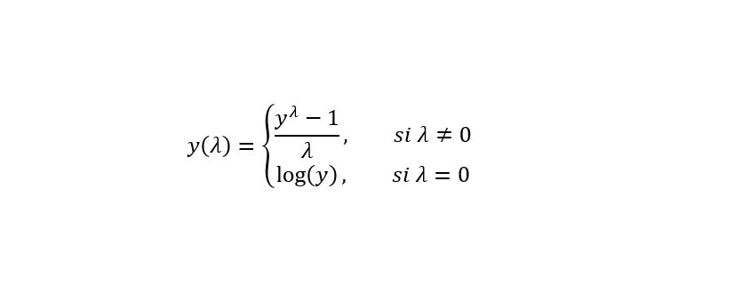

```r
knitr::include_graphics("BC1.JPG")
```

```r
#Figura 1: Transformación Box-Cox para datos positivos
#Fuente: https://www.statisticshowto.com/box-cox-transformation/
```

La transformación anterior únicamente es válida para valores positivos, sin embargo, Box y Cox propusieron una segunda fórmula que se puede usar para valores de y negativos:

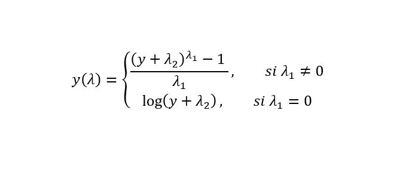

```r
knitr::include_graphics("BC2.JPG")
```

```r
#Figura 2: Transformación Box-Cox para datos positivos y/o negativos
#Fuente: https://www.statisticshowto.com/box-cox-transformation/
```

Mediante la sintaxis antes mencionada, así como variaciones sobre esta presentadas a continuación, es posible verificar cuál es el valor de $\lambda$ que produce la mayor verosimilitud en la estimación de los coeficientes.

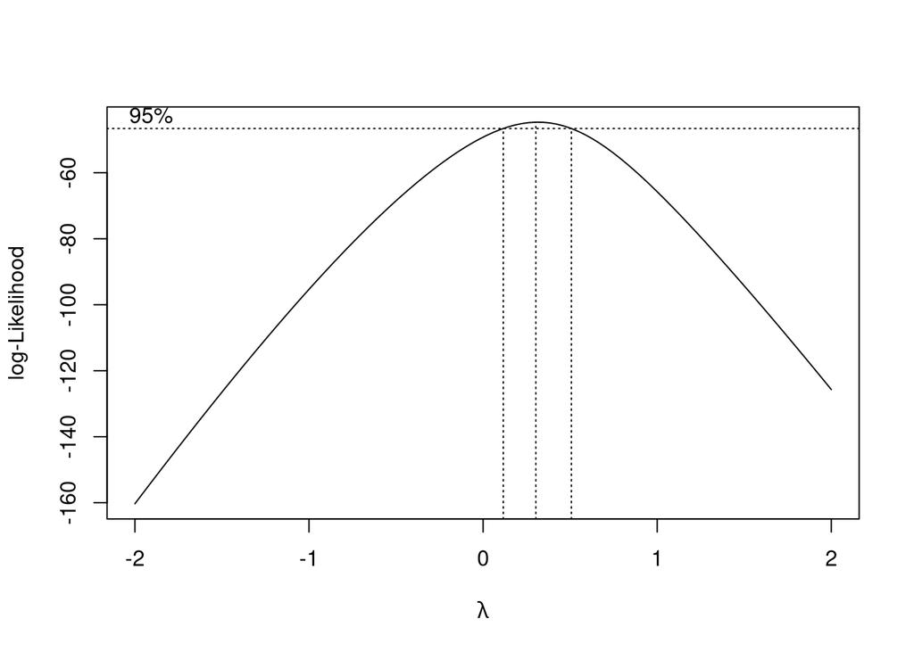

```r
library(MASS)
bc=boxcox(mod1)
```

```r
#Obteniendo el valor numérico de lambda
names(bc)
```

```
## [1] "x" "y"
```

```r
bc$x[bc$y==max(bc$y)]
```

```
## [1] 0.3030303
```

El valor que produce la máxima verosimilitud está cerca de 0.30.

Adicionalmente, si se traza una línea vertical para el valor $\lambda=0.5$ se observa que se encuentra dentro del intervalo que se aproxima a la máxima verosimilitud.

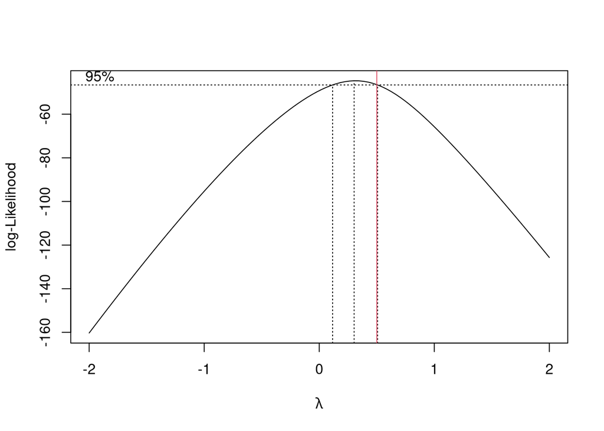

```r
boxcox(mod1)
abline(v=0.5,col=2)
```

A pesar de no ser el valor óptimo, un valor $\lambda=0.5$ produce un nivel de verosimilitud bastante cercano al máximo y, a causa de la facilidad de estimación computacional de un $λ=0.5$, se trabajará con tal valor de $λ$. Las transformaciones Box-Cox se pueden desagregar (y en el caso de la transformación para positivos y/o negativos re-expresar) en los siguientes tipos:

1. La trasformación completa de Box-Cox

$$y^{(\lambda)}=\frac{y^\lambda-1}{\lambda\tau^{\lambda-1}}$$
,

donde $\tau$ es la media geométrica de $y$. Esta reexpresión es posible a causa de lo establecido en (Box & Cox, 1964, p. 216).

2. La transformación incompleta que elimina la parte del $\tau$

$$y^{(\lambda)}=\frac{y^\lambda-1}{\lambda}$$

3. La transformación simple que sólo eleva la respuesta a la $\lambda$:

   $$y^{(\lambda)}=y^\lambda$$

Así, es posible crear tres nuevas variables con estas transformaciones. Para ello es útil dividir la pantalla en cuatro partes mediante la sintaxis `par(mfrow=c(2,2))`. Posteriormente, pueden construirse cuatro gráficos, en donde en el eje X se localice siempre la variable **elevacion** y en cada uno de los gráficos vaya cambiando el eje Y para observar la variable de respuesta original y cada una de sus tres transformaciones.

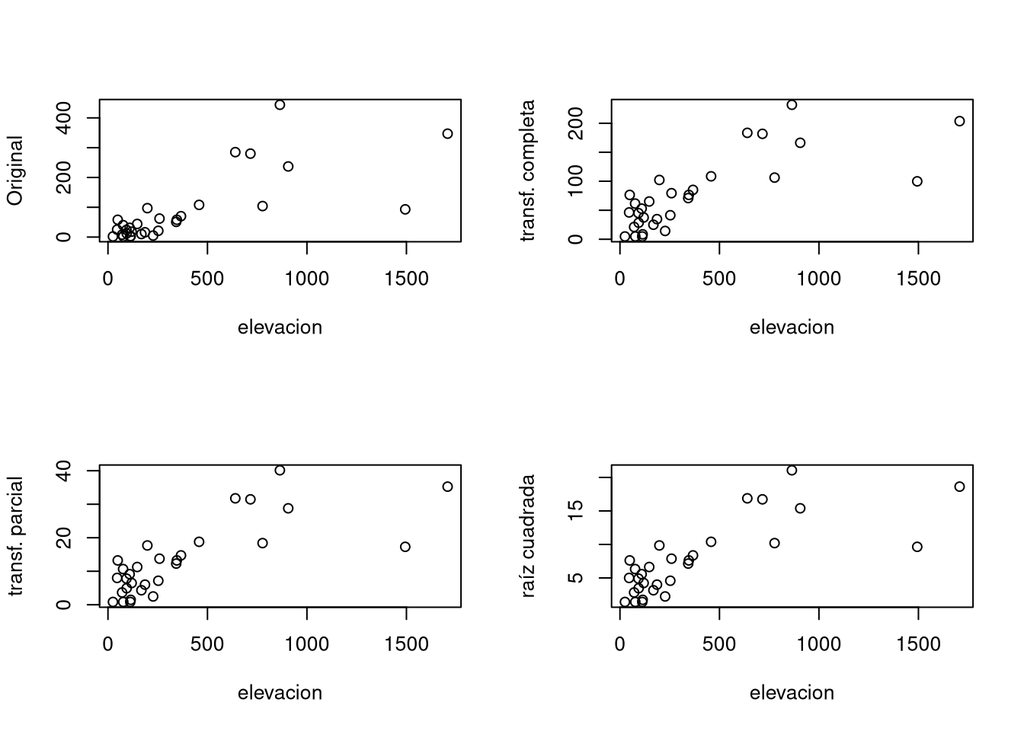

```r
lambda = 0.5
n = nrow(base)
tau = prod(especies)^(1/n)
tcom = (especies^lambda-1)/(lambda*tau^(lambda-1))
tincom = (especies^lambda-1)/lambda
rq = sqrt(especies)
par(mfrow=c(2,2))
plot(elevacion,especies,ylab="Original")
plot(elevacion,tcom,ylab="transf. completa")
plot(elevacion,tincom,ylab="transf. parcial")
plot(elevacion,rq,ylab="raíz cuadrada")
```

```r
par(mfrow=c(1,1))
```

Complementariamente, puede ajustarse el modelo de regresión utilizando las transformaciones antes descritas y tras ello encontrar los coeficientes de regresión utilizando MLE.

```r
mod4 = lm(tcom ~ .-endemicas-especies,base)
mod5 = lm(tincom ~ .-endemicas-especies,base)
mod6 = lm(rq ~ .-endemicas-especies,base)
logLik(mod4)
```

```
## 'log Lik.' -143.2339 (df=7)
```

```r
logLik(mod5)
```

```
## 'log Lik.' -90.6196 (df=7)
```

```r
logLik(mod6)
```

```
## 'log Lik.' -69.82518 (df=7)
```

¿Debe existir alguna preocupación porque se obtuvo una verosimilitud más baja con alguna de las trasformaciones? Al respecto debe responderse, como complemento a lo antes explicado en relación al uso de algún criterio de información, que las estimaciones por máxima verosimilitud sólo son comparables dentro de la familia de transformaciones completas.

Adicionalmente, puede realizarse el contraste de Breusch-Pagan (o de White) para los modelos transformados por el método Box-Cox.

```r
library(lmtest)
#Contraste Breusch-Pagan
bptest(mod4,studentize = F)
```

```
##
##  Breusch-Pagan test
##
## data:  mod4
## BP = 5.4195, df = 5, p-value = 0.3669
```

```r
bptest(mod5,studentize = F)
```

```
##
##  Breusch-Pagan test
##
## data:  mod5
## BP = 5.4195, df = 5, p-value = 0.3669
```

```r
bptest(mod6,studentize = F)
```

```
##
##  Breusch-Pagan test
##
## data:  mod6
## BP = 5.4195, df = 5, p-value = 0.3669
```

```r
#Contraste de White
bptest(mod4,studentize = T)
```

```
##
##  studentized Breusch-Pagan test
##
## data:  mod4
## BP = 6.6766, df = 5, p-value = 0.2458
```

```r
bptest(mod5,studentize = T)
```

```
##
##  studentized Breusch-Pagan test
##
## data:  mod5
## BP = 6.6766, df = 5, p-value = 0.2458
```

```r
bptest(mod6,studentize = T)
```

```
##
##  studentized Breusch-Pagan test
##
## data:  mod6
## BP = 6.6766, df = 5, p-value = 0.2458
```

Como se verifica, en todos los casos se obtiene el mismo resultado para cada bloque de contrastes y ha desparecido la heteroscedasticidad.

# CASO DE APLICACIÓN: ANÁLISIS DE LA ESPERANZA DE VIDA ENTRE PAÍSES

La base `esperanza.Rdata` contiene información para 150 países de los 5 continentes y se busca establecer las relaciones que existen entre ciertas variables del país y la esperanza de vida. A continuación se le da una descripción de las variables que aparecen en la base en el orden en que aparecen:

- **pais** - Identificador de país, en realidad no es una variable.
- **esper** - Esperanza de vida al nacer expresada en años.
- **cont** - Continente.
- **pob** - Densidad de población por Km$^2$.
- **pib** - Producto Interno Bruto per capita (cientos de dólares).
- **analf** - Tasa de analfabetismo (%).
- **desem** - Tasa de desempleo (%).

Puede estimarse un modelo que tenga como respuesta **esper** como respuesta y los siguientes cuatro predictores: **pob**, **pib**, **analf** y **desem**. Adicionalmente, es recomendable realizar el gráfico de los residuales contra los valores ajustados con la finalidad de buscar algún patrón visual de heterocedasticidad, al igual que el gráfico Quantil-Quantil para los mismos fines, antes de realizar el contraste de Breusch-Pagan o el contraste de White.

```r
library(car)
```

```r
load("esperanza.Rdata")
attach(base)
mod7= lm(esper~pob+pib+analf+desem)
par(mfrow=c(1,2))
plot(mod7$fit,mod7$res,xlab="ajustados",ylab="residuales")
bptest(mod7,studentize=F)
```

```
##
##  Breusch-Pagan test
##
## data:  mod7
## BP = 56.379, df = 4, p-value = 1.67e-11
```

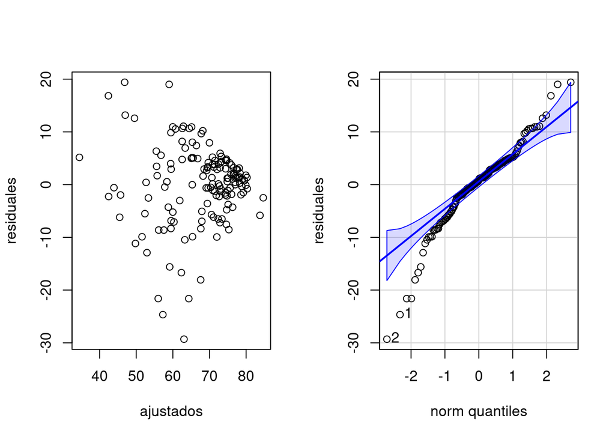

```
## [1] 2 1
```

```r
qqPlot(mod7$res,ylab="residuales")
```

El primer gráfico parece describir un patrón de heterocedasticidad, ya que la variabilidad a la derecha es menor que en el centro o a la izquierda. La prueba de Breush-Pagan se rechaza con una probabilidad asociada muy baja ($p<0.0001$). En el segundo gráfico se observa lo que parece ser un patrón de no-normalidad por cuanto en la cola izquierda existe una tendencia de puntos a estar debajo de la línea recta. Sin embargo, cualquier conclusión respecto a la normalidad debe tomarse con reservas porque existe evidencia gráfica importante de que no se cumple el supuesto de homogeneidad de varianza, mientras que las pruebas de normalidad asumen por definición que existe homocedasticidad.

Por los resultados anteriores, podría ser recomendable realizar una transformación de Box-Cox. Al realizar esta transformación, para el caso del presente conjunto de datos, se obtendrá una gráfica en la que no se podría apreciar de forma visual el valor de lamba que maximiza la estimación por log-verosimilitud de los coeficientes de regresión. Para solventar este problema, puede especificarse al interior de `boxcox` que `lambda=seq(1,10,0.5)` para que extienda el rango de 1 a 10 de 0.5 en 0.5.

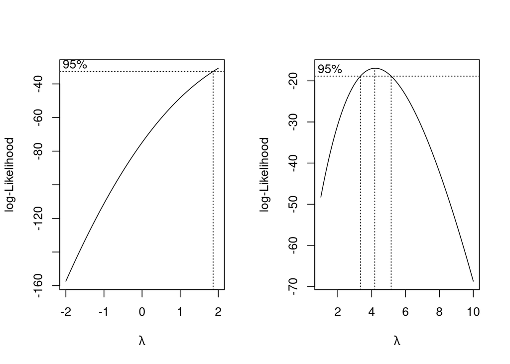

```r
par(mfrow=c(1,2))
library(MASS)
boxcox(mod7)
boxcox(mod7,lambda=seq(1,10,.5))
```

Como puede observarse, el valor máximo de $λ$ se encuentra cerca por la derecha de 4. Por ello, resulta recomendable realizar una transformación Box-Cox para un $λ=4$ y verificar tras ello tras la misma se cumple el supuesto de homogeneidad de varianza y normalidad (este último sujeto a que se cumpla el primero, como se adelantó.

```r
z4=esper^4
mod8 = lm(z4~pob+pib+analf+desem)
par(mfrow=c(1,2))
plot(mod8$fit,mod8$res,xlab="ajustados",ylab="residuales")
bptest(mod8,studentize=F)
```

```
##
##  Breusch-Pagan test
##
## data:  mod8
## BP = 18.551, df = 4, p-value = 0.0009629
```

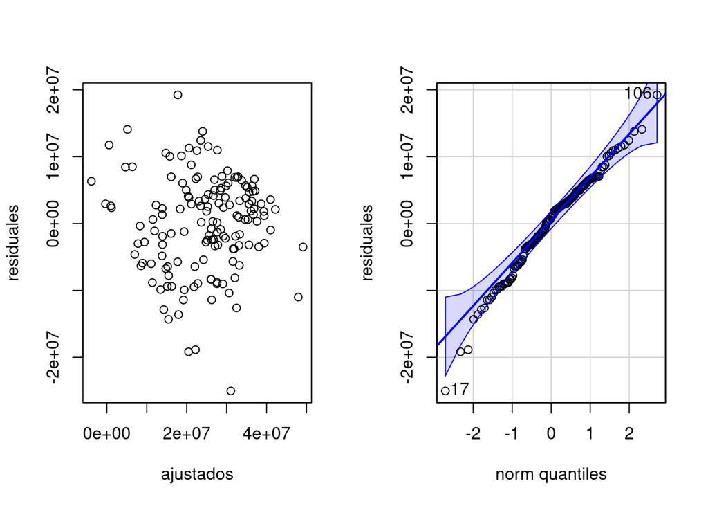

```
## [1]  17 106
```

```r
qqPlot(mod8$res,ylab="residuales")
```